# Štatistická analýza hier

Štatistické metódy

Nazarii Kretsul

2024-01-04

# Úlohy

1. Využitím popisnej štatistiky charakterizujte premennú Critics’ assessment . Výsledky zobrazte graficky a popíšte aj použité grafy. Aký je najčastejší budget pre daný súbor?
2. Vhodným testom overte na hladine významnosti 0.1, či je Critics’ assessment najviac 87. Porovnajte Critics’ assessment RPG a FPS genre. Je tento rozdiel štatisticky významný na hladine významnosti 0.01?
3. Existuje štatisticky významný rozdiel v budget vzhľadom na genre (berme len RPG,FPS a Action-Adventure) alebo vzhľadom na úroveň premennej RTX on? Overte vhodným testom a aj graficky. Ak rozdiel existuje, tak medzi ktorými? Existuje aj interakcia medzi týmito premennými?
4. Je medzi Critics’ a players’ assessment hier, ktoré majú budget pod 80 000 štatisticky významný vzťah? Ak áno, popíšte slovne ako sa prejavuje a popíšte ho vhodným modelom. Vhodnosť modelu overte.

# Riešenie

Načítanie knižnice a čítanie údajov zo súboru

```r
library(readODS)
library(tidyverse)
library(knitr)
library(kableExtra)
data <- read_ods("games.ods", sheet = 1, range = "A1:G60")
data %>% #Na vypísanie tabuľky používam funkciu kable(), pretože posledný stĺpec nebol zobrazený cez head()
  slice(1:10) %>%
  kable(format = "html", escape = FALSE) %>%
  kable_styling("striped", full_width = FALSE)
```

| Game.title | Genre | RTX.on | AMD.FSR.on | Game.budget | Critics..assessment | Players..assessment |
| --- | --- | --- | --- | --- | --- | --- |
| Cyberpunk 2077 | RPG | 1 | 0 | 1e+05 | 85 | 75 |
| The Witcher 3 | RPG | 0 | 1 | 6e+04 | 90 | 92 |
| Doom Eternal | FPS | 1 | 1 | 7e+04 | 88 | 85 |
| Grand Theft Auto V | Action | 0 | 0 | 8e+04 | 95 | 90 |
| Red Dead Redemption 2 | Action-Adventure | 1 | 0 | 9e+04 | 97 | 88 |
| Valorant | FPS | 0 | 1 | 1e+04 | 75 | 89 |
| Call of Duty: Warzone | FPS | 1 | 1 | 4e+04 | 85 | 87 |
| Apex Legends | Battle Royale | 0 | 0 | 2e+04 | 80 | 91 |
| Fortnite | Battle Royale | 1 | 0 | 3e+04 | 70 | 86 |
| League of Legends | MOBA | 0 | 1 | 5e+03 | 90 | 95 |

## Úloha 1

Využitím popisnej štatistiky charakterizujte premennú Critics’ assessment . Výsledky zobrazte graficky a popíšte aj použité grafy.

```r
data$Critics..assessment # Vypís Critics assessment
```

```
##  [1] 85 90 88 95 97 75 85 80 70 90 95 80 70 95 92 75 85 80 90 88 96 93 94 87 85
## [26] 89 92 88 86 87 83 88 87 91 93 90 94 92 93 88 91 89 95 90 88 92 95 88 90 94
## [51] 89 95 91 94 90 92 88 89 90
```

Vďaka funkcii summary() získame priemer, medián, 1. a 3. kvantil, minimálne a maximálne hodnoty, čo stačí na prácu s hodnoteniami kritikov:

```r
summary(data$Critics..assessment)
```

```
##    Min. 1st Qu.  Median    Mean 3rd Qu.    Max.
##   70.00   87.00   90.00   88.66   92.50   97.00
```

Kvôli prehľadnosti použijeme jednoduchý graf hist(), pretože umožňuje ľahko vidieť frekvenciu hodnotení kritikov.

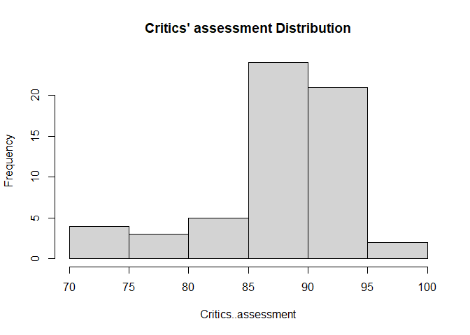

```r
hist(data$Critics..assessment, main = "Critics' assessment Distribution", xlab = "Critics..assessment")
```

Rozpis hodnotenia nie je symetrický, s tendenciou k vyšším hodnotám. Prvým záverom je, že kritici len zriedka udeľujú nízke ocenenia

Aký je najčastejší budget pre daný súbor?

Ak chceme vidieť najčastejšie sa vyskytujúci rozpočet pre daný súbor, vytvorme tabuľku s frekvenciami jednotlivých hodnôt a zobrazme ich aj graficky

```r
budget_table <- table(data$Game.budget)
budget_table # Už tu vidíme, že existujú 3 hodnoty s maximálnou frekvenciou
```

```
##
##  5000 10000 15000 20000 25000 30000 35000 40000 45000 50000 55000 60000 65000
##     1     4     3     6     3     6     1     3     2     5     2     4     2
## 70000 75000 80000 85000 90000 1e+05
##     6     2     3     1     3     2
```

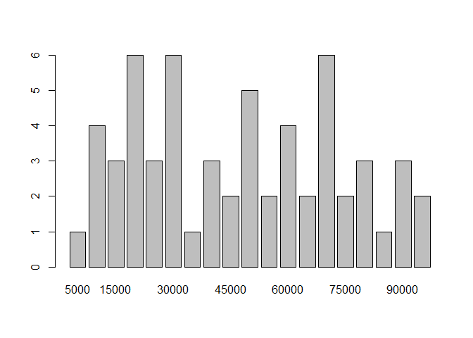

```r
barplot(budget_table)
```

## Úloha 2

Vhodným testom overte na hladine významnosti 0.1, či je Critics’ assessment najviac 87.

Keďže nepoznáme rozptyl, na vykonanie tohto testu použijeme t.test()

H0: stredna Critics’ assessment = 87

H1: Critics’ assessment > 87

```r
t.test(data$Critics..assessment, mu = 87, alternative = "greater", conf.level = 0.9)
```

```
##
##  One Sample t-test
##
## data:  data$Critics..assessment
## t = 2.1613, df = 58, p-value = 0.01741
## alternative hypothesis: true mean is greater than 87
## 90 percent confidence interval:
##  87.66474      Inf
## sample estimates:
## mean of x
##  88.66102
```

P hodnota < 0.1, takže H0 zamietame. Alternativna hypotéza - stredna hodnota 88.66102

Porovnajte Critics’ assessment RPG a FPS genre.

Najprv skontrolujme, či údaje pochádzajú z normálneho rozdelenia

H0: všetky testy z normálneho rozdelenia

H1: nie

```r
shapiro.test(data$Critics..assessment[data$Genre == "RPG"]) # Rozdelenie je normálne, P-hodnota>0.05
```

```
##
##  Shapiro-Wilk normality test
##
## data:  data$Critics..assessment[data$Genre == "RPG"]
## W = 0.93542, p-value = 0.5667
```

```r
shapiro.test(data$Critics..assessment[data$Genre == "FPS"]) # Rozdelenie nie je normálne, P-hodnota<0.05
```

```
##
##  Shapiro-Wilk normality test
##
## data:  data$Critics..assessment[data$Genre == "FPS"]
## W = 0.83034, p-value = 0.02359
```

H0: Critics’ assessment(RPG)=Critics’ assessment(FPS)

H1: Critics’ assessment(RPG)≠Critics’ assessment(FPS)

```r
wilcox.test(data$Critics..assessment[data$Genre == "RPG"],
            data$Critics..assessment[data$Genre == "FPS"])
```

```
##
##  Wilcoxon rank sum test with continuity correction
##
## data:  data$Critics..assessment[data$Genre == "RPG"] and data$Critics..assessment[data$Genre == "FPS"]
## W = 59, p-value = 0.2291
## alternative hypothesis: true location shift is not equal to 0
```

Keďže P hodnota > 0.01, H0 nezamietame - neexistuje štatisticky významný rozdiel na hladine významnosti 0.01. Test nám teda hovorí, že stredné hodnoty sú dostatočne rovnaké

## Úloha 3

Existuje štatisticky významný rozdiel v budget vzhľadom na genre (berme len RPG, FPS a Action-Adventure) alebo vzhľadom na úroveň premennej RTX on?

Vytvorime tabuľku len s tromi hernými žánrami

```r
data_3genre <- data[data$Genre %in% c("RPG", "FPS", "Action-Adventure"), ]
data_3genre %>%
  slice(1:10) %>%
  kable(format = "html", escape = FALSE) %>%
  kable_styling("striped", full_width = FALSE)
```

| Game.title | Genre | RTX.on | AMD.FSR.on | Game.budget | Critics..assessment | Players..assessment |
| --- | --- | --- | --- | --- | --- | --- |
| Cyberpunk 2077 | RPG | 1 | 0 | 1e+05 | 85 | 75 |
| The Witcher 3 | RPG | 0 | 1 | 6e+04 | 90 | 92 |
| Doom Eternal | FPS | 1 | 1 | 7e+04 | 88 | 85 |
| Red Dead Redemption 2 | Action-Adventure | 1 | 0 | 9e+04 | 97 | 88 |
| Valorant | FPS | 0 | 1 | 1e+04 | 75 | 89 |
| Call of Duty: Warzone | FPS | 1 | 1 | 4e+04 | 85 | 87 |
| The Elder Scrolls V: Skyrim | RPG | 1 | 1 | 3e+04 | 92 | 88 |
| Valorant | FPS | 0 | 0 | 1e+04 | 75 | 87 |
| The Elder Scrolls V: Skyrim | RPG | 0 | 0 | 3e+04 | 88 | 79 |
| The Legend of Zelda | Action-Adventure | 1 | 1 | 8e+04 | 96 | 94 |

Opäť skontrolujme, či sú údaje normálne rozdelené

H0: všetky testy z normálneho rozdelenia

H1: nie

```r
shapiro.test(data_3genre$Game.budget[data$Genre == "RPG"]) # Rozdelenie je normálne
```

```
##
##  Shapiro-Wilk normality test
##
## data:  data_3genre$Game.budget[data$Genre == "RPG"]
## W = 0.91838, p-value = 0.5279
```

```r
shapiro.test(data_3genre$Game.budget[data$Genre == "FPS"]) # Rozdelenie je normálne
```

```
##
##  Shapiro-Wilk normality test
##
## data:  data_3genre$Game.budget[data$Genre == "FPS"]
## W = 0.86349, p-value = 0.2411
```

```r
shapiro.test(data_3genre$Game.budget[data$Genre == "Action-Adventure"]) # Rozdelenie je normálne
```

```
##
##  Shapiro-Wilk normality test
##
## data:  data_3genre$Game.budget[data$Genre == "Action-Adventure"]
## W = 0.96429, p-value = 0.6369
```

```r
shapiro.test(data$Game.budget[data$RTX.on == 1]) # Rozdelenie je normálne
```

```
##
##  Shapiro-Wilk normality test
##
## data:  data$Game.budget[data$RTX.on == 1]
## W = 0.93129, p-value = 0.05314
```

```r
shapiro.test(data$Game.budget[data$RTX.on == 0]) # Rozdelenie nie je normálne
```

```
##
##  Shapiro-Wilk normality test
##
## data:  data$Game.budget[data$RTX.on == 0]
## W = 0.91129, p-value = 0.01846
```

Z týchto testov môžeme vyvodiť záver, že pre herné žánre môžeme použiť testy s normálnym rozdelením a pre hry s technológiou RTX alebo bez nej použijeme testy pre údaje z nenormálneho rozdelenia

Urobme test aov(), keďže rozpočet so závislosťou pre tieto tri žánre má normálne rozdelenie

H0: Game budget(RPG)=Game budget(FPS)=Game budget(Action-Adventure)

H1: Game budget(RPG)≠Game budget(FPS)≠Game budget(Action-Adventure)

```r
anv_model <- aov(Game.budget ~ Genre, data = data_3genre)
summary(anv_model)
```

```
##             Df    Sum Sq   Mean Sq F value Pr(>F)
## Genre        2 2.122e+09 1.061e+09   1.988  0.159
## Residuals   24 1.281e+10 5.336e+08
```

Hodnota F-štatistiky je pomerne nízka - 1,988 a P-hodnota je > 0.05, takže medzi skupinami žánrov nie sú štatisticky významné rozdiely, pokiaľ ide o herný rozpočet.

Teraz vytvorme graf

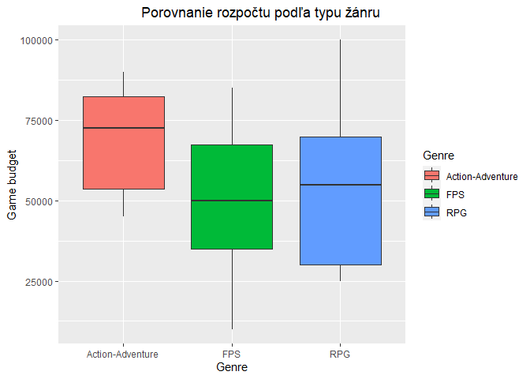

```r
ggplot(data_3genre, aes(x=Genre, y=Game.budget))+
  geom_boxplot(aes(fill = Genre)) +
  labs(x= "Genre", y= "Game budget", title = "Porovnanie rozpočtu podľa typu žánru")+
  theme(plot.title = element_text(hjust=0.77))
```

Ukazuje sa, že hoci v žánri FPS existujú extrémne hodnoty, väčšina rozpočtových hodnôt pre každý žáner leží približne na rovnakej hranici, ako ukazuje posledný test.

Urobme Kruskal-Wallis test, keďže rozpočet so závislosťou pre RTX.on má nenormálne rozdelenie

H0: Game budget(RTX on)=Game budget(RTX off)

H1: Game budget(RTX on)≠Game budget(RTX off)

```r
kruskal.test(Game.budget ~ RTX.on, data = data)
```

```
##
##  Kruskal-Wallis rank sum test
##
## data:  Game.budget by RTX.on
## Kruskal-Wallis chi-squared = 4.5282, df = 1, p-value = 0.03334
```

P-hodnota je < 0.05, a to ukazuje, že existuje štatisticky významný rozdiel v rozpočtoch hier v závislosti od prítomnosti technológie RTX v hre

Vytvorme graf pre Budget~RTX.on

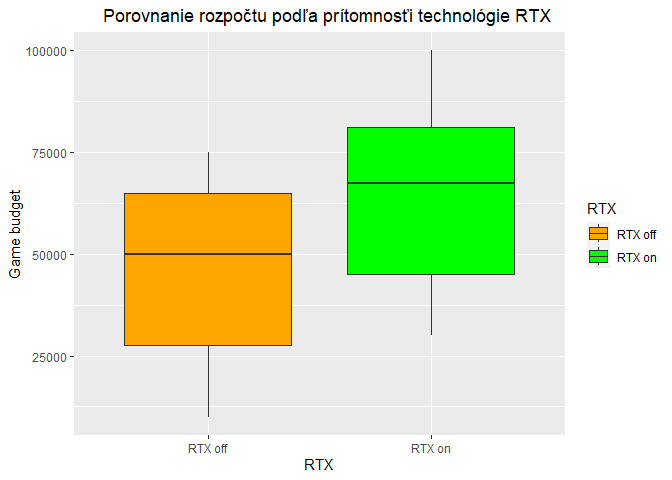

```r
ggplot(data_3genre, aes(x=factor(RTX.on), y=Game.budget, fill = factor(RTX.on))) +
  geom_boxplot() +
  labs(x= "RTX", y= "Game budget", title = "Porovnanie rozpočtu podľa prítomnosťi technológie RTX") +
  theme(plot.title = element_text(hjust=0.67)) +
  scale_x_discrete(labels = c("RTX off", "RTX on")) +
  scale_fill_manual(values = c("0" = "orange", "1" = "green"), name = "RTX", labels = c("RTX off", "RTX on"))
```

Z tohto grafu vidíme, že hry s technológiou RTX majú vyšší rozpočet ako hry bez nej

Na testovanie interakcie medzi žánrami a dostupnosťou RTX na technológii opäť použijeme anova

```r
anv_model_interakcia <- aov(Game.budget ~ Genre * RTX.on, data = data_3genre)
summary(anv_model_interakcia)
```

```
##              Df    Sum Sq   Mean Sq F value Pr(>F)
## Genre         2 2.122e+09 1.061e+09   2.382 0.1168
## RTX.on        1 2.928e+09 2.928e+09   6.574 0.0181 *
## Genre:RTX.on  2 5.249e+08 2.624e+08   0.589 0.5637
## Residuals    21 9.354e+09 4.454e+08
## ---
## Signif. codes:  0 '***' 0.001 '**' 0.01 '*' 0.05 '.' 0.1 ' ' 1
```

V prípade interakcie medzi Genre a RTX.on je p-hodnota 0,5637, čo je oveľa viac ako hladina významnosti 0,05. To znamená, že medzi týmito dvoma faktormi neexistuje štatisticky významná interakcia.

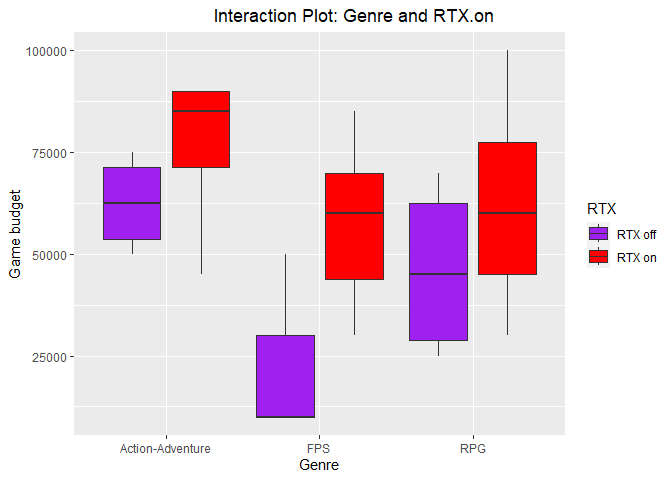

```r
ggplot(data_3genre, aes(x = Genre, y = Game.budget, fill = factor(RTX.on))) +
  geom_boxplot(position = position_dodge(0.9)) +
  labs(x = "Genre", y = "Game budget", title = "Interaction Plot: Genre and RTX.on") +
  theme(plot.title = element_text(hjust = 0.666))+
  scale_fill_manual(values = c("0" = "purple", "1" = "red"), name = "RTX", labels = c("RTX off", "RTX on"))
```

## Úloha 4

Je medzi Critics’ a players’ assessment hier, ktoré majú budget pod 80 000 štatisticky významný vzťah? Ak áno, popíšte slovne ako sa prejavuje a popíšte ho vhodným modelom. Vhodnosť modelu overte.

```r
data_budget_lesseq_80000 <- data[data$Game.budget <= 80000, ]
data_budget_lesseq_80000 %>%
  slice(1:10) %>%
  kable(format = "html", escape = FALSE) %>%
  kable_styling("striped", full_width = FALSE)
```

| Game.title | Genre | RTX.on | AMD.FSR.on | Game.budget | Critics..assessment | Players..assessment |
| --- | --- | --- | --- | --- | --- | --- |
| The Witcher 3 | RPG | 0 | 1 | 60000 | 90 | 92 |
| Doom Eternal | FPS | 1 | 1 | 70000 | 88 | 85 |
| Grand Theft Auto V | Action | 0 | 0 | 80000 | 95 | 90 |
| Valorant | FPS | 0 | 1 | 10000 | 75 | 89 |
| Call of Duty: Warzone | FPS | 1 | 1 | 40000 | 85 | 87 |
| Apex Legends | Battle Royale | 0 | 0 | 20000 | 80 | 91 |
| Fortnite | Battle Royale | 1 | 0 | 30000 | 70 | 86 |
| League of Legends | MOBA | 0 | 1 | 5000 | 90 | 95 |
| Minecraft | Sandbox | 1 | 1 | 25000 | 95 | 92 |
| Among Us | Social Deduction | 0 | 0 | 10000 | 80 | 88 |

```r
krit <- data_budget_lesseq_80000$Critics..assessment
hravc<- data_budget_lesseq_80000$Players..assessment  # ulozim vektory hodnot v premenne
```

Overme, či sú výsledky hráčov a kritikov z normálneho rozdelenia

H0: všetky testy test z normálneho rozdelenia

H1: nie

```r
shapiro.test(krit) # Rozdelenie nie je normálne
```

```
##
##  Shapiro-Wilk normality test
##
## data:  krit
## W = 0.85945, p-value = 1.737e-05
```

```r
shapiro.test(hravc) # Rozdelenie je normálne, ale velmi blizko do nenormálneho
```

```
##
##  Shapiro-Wilk normality test
##
## data:  hravc
## W = 0.95633, p-value = 0.05063
```

Pearsonov korelačný koeficient nemôžeme použiť, pretože je citlivý na vybočujúce hodnoty, preto použijeme Spearmanov a Kendallov, aby overiť, či existuje korelácia medzi hodnoteniami kritikov a hráčov v prípade hier s rozpočtom nižším ako 80 000.

H0: medzi a a b je štatisticky významný vzťah

H1: nie je medzi a a b štatisticky významný vzťah

```r
cor(krit, hravc, method= "spearman")
```

```
## [1] 0.7508752
```

```r
cor(krit, hravc, method = "kendall")
```

```
## [1] 0.5896649
```

Vidíme, že hodnoty oboch testov sú bližšie k 1 ako k 0, čo znamená, že medzi hodnoteniami kritikov a hráčov štatisticky významný vzťah.

Teraz, keď sme zistili štatisticky významný vzťah, môžeme vytvoriť model

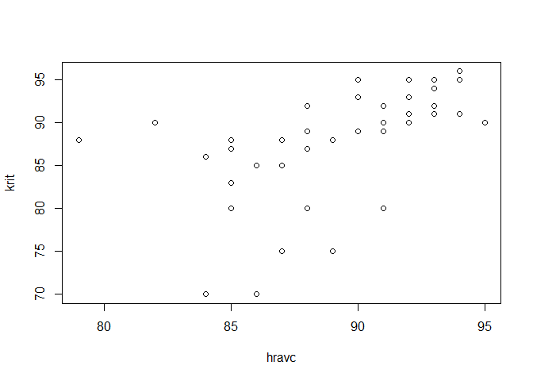

```r
plot(krit~hravc)
```

Z grafu je ťažké presne určiť, aký je vzťah medzi týmito odhadmi, ale pravdepodobne je mocninovy.

```r
krity <- krit^11  # Tu sa ukázalo, že stupeň 11 je pre tento vzťah najpravdepodobnejší, pre ostatné stupne shapirov test ukázal nižšiu hodnotu p
hravcx <- hravc^11

model <- lm(krity ~ hravcx)
```

H0: všetky testy test z normálneho rozdelenia

H1: nie

```r
shapiro.test(model$residuals)
```

```
##
##  Shapiro-Wilk normality test
##
## data:  model$residuals
## W = 0.96948, p-value = 0.1916
```

P hodnota > 0.05, takže model je vhodný

```r
summary(model)
```

```
##
## Call:
## lm(formula = krity ~ hravcx)
##
## Residuals:
##        Min         1Q     Median         3Q        Max
## -2.590e+21 -5.086e+20 -2.938e+20  7.157e+20  2.611e+21
##
## Coefficients:
##              Estimate Std. Error t value Pr(>|t|)
## (Intercept) 2.017e+20  4.585e+20   0.440    0.662
## hravcx      9.163e-01  1.375e-01   6.665 1.84e-08 ***
## ---
## Signif. codes:  0 '***' 0.001 '**' 0.01 '*' 0.05 '.' 0.1 ' ' 1
##
## Residual standard error: 1.175e+21 on 51 degrees of freedom
## Multiple R-squared:  0.4655, Adjusted R-squared:  0.455
## F-statistic: 44.42 on 1 and 51 DF,  p-value: 1.842e-08
```

Záverom je, že model ukazuje, že existuje štatisticky významný a pozitívny vzťah medzi hodnotením kritikov a hodnotením hráčov pre hry s rozpočtom do 80 000 a model môže byť užitočný na predpovedanie hodnôt.